# Epidemic impacts in different regions

April 28, 2020

This post is long and rambling and my thoughts have evolved while writing. Here’s the summary:

- new cases per million are much higher in some areas of the US and Europe than others. Your view of this epidemic will be colored by what’s going on in your area.
- Current and projected deaths per 1000 are quite different in different areas. Some regions that seem ‘cavelier’ have quite low current and project deaths per 1000, so you can argue that their approach reflects a feeling that they have things under control in their state.
- Things are bad all along the northeast sea board, but you knew that I’m sure. It’s spreading southward. Sorry.
- What the heck Illinois and Indiana? I don’t understand you. I get Florida. I get Georgia. They actually have low deaths rates so their ‘things are ok’ attitude is understandable. But you are on track to lose more per capita than NY+NJ+PA. True it is spread out over the year, but still, why no anxiety about this? Purdue has announced plans to open in fall 2020, citing ‘zero lethal threat’. An average of 30 people a day are dying of COVID-19 in Indiana. If that keeps up, and there is no sign of it stopping, you will hit 7x your normal influenza deaths.
- Los Angeles County is still going up. Sigh. Like 6000 new cases last week. That’s 10x what was in the bay area. Please stop so the rest of CA can get off lockdown sometime this summer.
- At home in WA, things are good. New cases going down. People are wearing their masks in Seattle and staying fairly distant (more or less). I have hopes for getting off lockdown in May (fingers crossed). European countries are starting to loosen up at 20 new cases per million and we are about that. Ok, we don’t have “test, trace, isolate” in place, but really most of Europe doesn’t either. If they can loosen up and keep things in control, it bodes well for us.

Ok and now the long post. Maybe later I’ll break this out.

This past week, I have been reflecting on the different local perceptions that people have of the epidemic in their local area. This is in part based on what FB friends have posted and commented and on chatting with friends in other parts of the country. Some of my musing is based on the media, though I often find that the ‘real’ people featured in the media are often extreme while real people have views that are more nuanced and certainly not summarized by a click-bait headline.

Anyhow, it is clear that in some areas the view is that ‘What’s the big deal? The response is overblown.’ while in other areas friends are freaking out and praying ‘Please god, stop this epidemic. Stop the deaths.’ So I added a y-axis to my graphs that shows the new cases (and deaths) per million (and thousand). To me this really shows why in, say, FL the view is ‘This is not a big deal.’ while in NY, NJ, MA, CT, people are freaking out and can’t understand how people in other parts of the country can be so cavilier.

First, let’s put “new cases per million” and “deaths per thousand” in some context by looking at Europe. Instead of comparing to other diseases, which I don’t think makes much sense for a novel disease with no cure and so many unknowns, let’s look at countries that are put up as examples of a “bad case” (Italy, Spain and Belgium) and the examples of “good cases” (Denmark, Germany).

Caveat: I am going to show numbers using positive cases (“new cases”) and deaths across countries. Testing criteria vary across countries. Some, like Italy, were so swamped that tests were reserved for the worst cases. Others, like Germany, did broad testing. One way to try to adjust (mentally) is to scale by the CFR. These are all developed countries so CFRs should be similar (I think) and differences are probably due to testing. An exception is Italy, where home-care (more on that later) versus hospitalization, was associated with high mortality. Also ‘deaths’ are reported COVID-19 deaths, which are under-reported.

## Europe

Let’s start with Lombardy, the ‘poster region’ for a severe outbreak. Here is an interesting article what went wrong in Lombardy: https://apnews.com/de2794327607a3a67ed551f0b6b71404

At the peak of the epidemic, the new cases/million was 200. They have had 13449 deaths which is 0.67 per 1000 people; projected deaths are 20000 which will come out to 1 per 1000. This is considered the worst region in Europe. So 200/million new cases per day and 1 per 1000 deaths are big numbers. Let’s look at other ‘bad’ countries:

- Italy: peak 100 new cases/million; current 0.43 deaths/1000, projected 0.64 deaths/1000; CFR = 12
- Spain: peak 150 new cases/million; current 0.49 deaths/1000, projected 0.77 deaths/1000; CFR = 15
- Belgium: peak 125 new cases/million; current 0.58 deaths/1000, projected 1.18 deaths/1000; CFR = 18
- UK: peak 75 new cases/million; current 0.3 deaths/1000; projected 0.7 deaths/1000; CFR = 18

So these are the “bad” numbers. You can also see why Belgium is being mentioned as a country which is really being hit hard. Let’s look at “good” numbers:

- Germany: peak 70 new cases/million; current 0.07 deaths/1000, projected 0.08 deaths/1000; CFR = 4
- Denmark: peak 50 new cases/million; current 0.07 deaths/1000, projected 0.1 deaths/1000; CFR = 5.7
- Norway: peak 50 new cases/million; current 0.04 deaths/1000, projected 0.05 deaths/1000; CFR = 2.8

And let’s look at a few other countries:

- Czechia: peak 30 new cases/million; current 0.02 deaths/1000, projected 0.03 deaths/1000; CFR = 3.3
- Austria: peak 90 new cases/million; current 0.06 deaths/1000, projected 0.06 deaths/1000; CFR = 3.5
- Hungary: 10 new cases/million; no slowing though quite low reported prevalence
- Sweden: 75 new cases/million, not peaked yet; current 0.22 deaths/1000; projected ?? deaths/1000 (not peaked yet); CFR = 15.7

## United States

Let’s look at some other regions:

- SE Atlantic (GA+SC+NC+FL): peak 60 new cases/million; current 0.06 deaths/1000; projected 0.16 deaths/1000; CFR = 4.6
- FL: peak 50 new cases/million; current 0.03 deaths/1000; projected 0.05 deaths/1000; CFR = 4.2
- West South Central (TX+OK+AR): peak 30 new cases/million; current 0.02 deaths/1000; projected 0.12 deaths/1000; CFR = 3.9
- Mountain North (ID+MT+WY): peak 40 new cases/million; current 0.03 deaths/1000; projected 0.03 deaths/1000; CFR = 3.2
- Southern CA: 75 new cases/million, not peaked yet; current 0.05 deaths/1000; projected ?, hasn’t peaked
- Northern CA: peak 20 new cases/million; current 0.03 deaths/1000; projected 0.06/1000; CFR = 4.4
- WA: peak 50 new cases/million; current 0.03 deaths/1000; projected 0.05/1000; CFR = 6

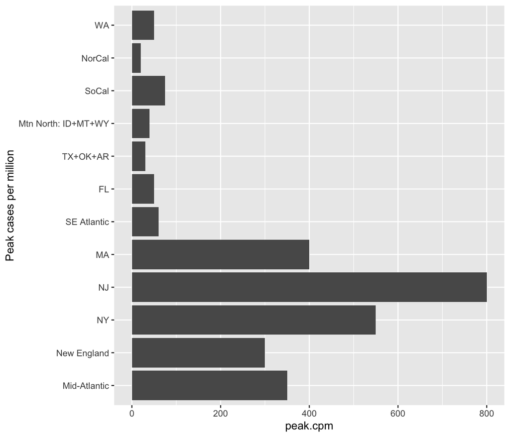

So you can see that there are really big differences. I think this explains why in some parts people (lay people not necessarily their health departments) feel like the epidemic and death rates are manageable and they can think of this more like a bad flu year (and take those kind of precautions). Certainly looking at the numbers in FL, I can understand that view.

But we don’t know why NY, NJ, CT, MA etc. ‘blew up’ and FL did not (or more precisely, has not as we don’t know what’s to come). FL has the elements to have ‘blown up’: lots of tourists bringing in infection, late closing of gatherings and plenty of cities. We just don’t understand this virus yet and many of the patterns we see in the US, don’t make a lot of sense.

But the numbers do illustrate why your view of the epidemic can be very different than in other parts of the US.

The response in WA, OR and Northern CA is interesting. Our numbers are like in parts of the country where a higher fraction of people feel like ‘this is no big deal’. The ‘vibe’ I get from Western WA though is a lot of concern. All my friends are locked down and around town, people wear masks and keep distant. My Seattle FB friends seem to look to NY and Italy and fear that future much more than my FB friends in other parts of the country with higher new cases/million. I can’t explain it, but I share it. We don’t understand why we have been ‘spared’ so far. There are conjectures and just-so stories, but we don’t really know. It is still early in this epidemic. Why has Massachusetts blow-up now when they were doing ok and went into shelter-in-place early? Why there when GA and FL didn’t blow up?

# Regional status:

Right now there are three areas in the US where the new cases are going down or are stabilized. Stabilized new cases are ‘workable’. As long as the health system is not overwhelmed, then the state can manage a steady rate. But new cases going up and up will eventually overwhelm any health system.

- **NY, NJ and PA** Although numbers are high, they are being driven down or are stabilized. Deaths per 1000 are headed to 0.75 to 1, but they are past the peak.
- **Rest of the east coast (MA, MD, DE, CT, RI)** Not good. High number of new cases per million. Not peaked yet though looks like soon. Deaths per 1000 are headed over 1.0. Based on NY+NJ+PA, I expect that it’ll stabilize, but the worst is ahead for them.
- **Moving down the Atlantic sea board (VA and NC)** It appears that the contagion is moving downward. VA is not peaking yet and now NC is ticking up again.
- **GA and FL** So far, numbers are in control statewide and are being driven down. I worry that FL (and other beach areas to the north) will be in trouble once tourism ramps back up. Their economy is heavily tourism-based so that is not good for the economy but I don’t see how they can avoid a major outbreak with heavy import of infections from the northeast. It seems like travel-restrictions within the US are unlikely (given that they are unconstitutional), so it is hard for me to see how the regions with low infection rates will avoid the fate of the northeast with time. The moment the planes start flying east to south and east to west, ….

[output not shown]

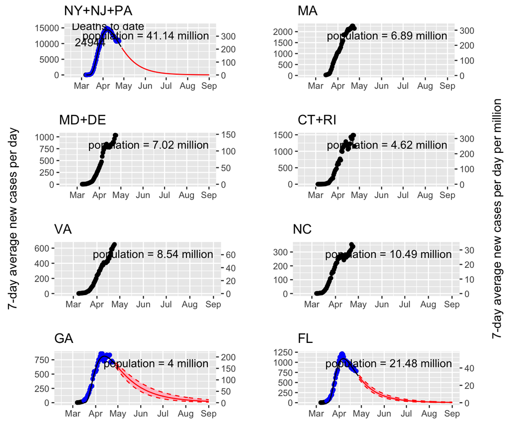

**West coast** In WA, OR and Northern CA, new cases per million are low and being driven down. Unfortunately Los Angeles County has been ticking upward. Last M-F, the 5 day total jumped to 6200 from 2500 the previous week. If it jumps again this week, that’s bad. In contrast, new cases are quite low in many CA counties. And even in the Bay Area (Santa Clara, Alameda, San Francisco), the 5-day total was only ca 600. But the CA lockdown was extended to June 1. In some states (Iowa), they are removing restrictions in counties with few states but unless Los Angeles County can be quarantined, I can’t see how that would work in CA.

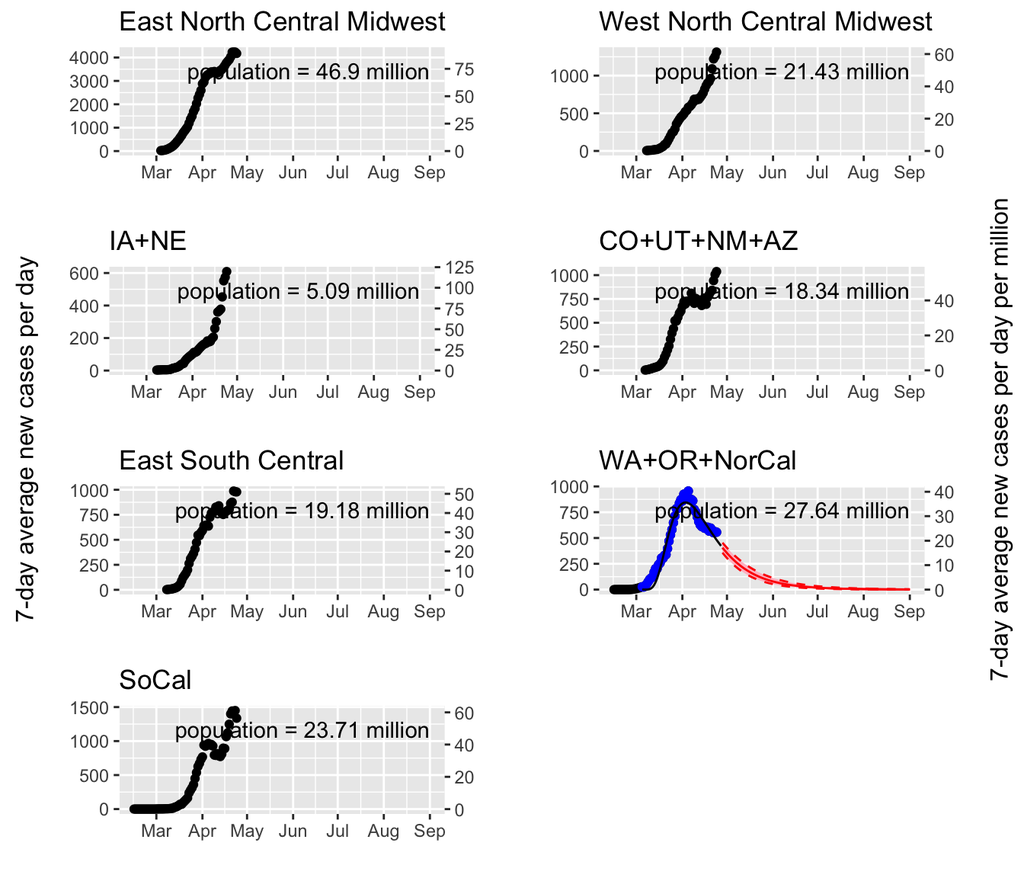